# White Wine Quality

#### 氯化物与品质

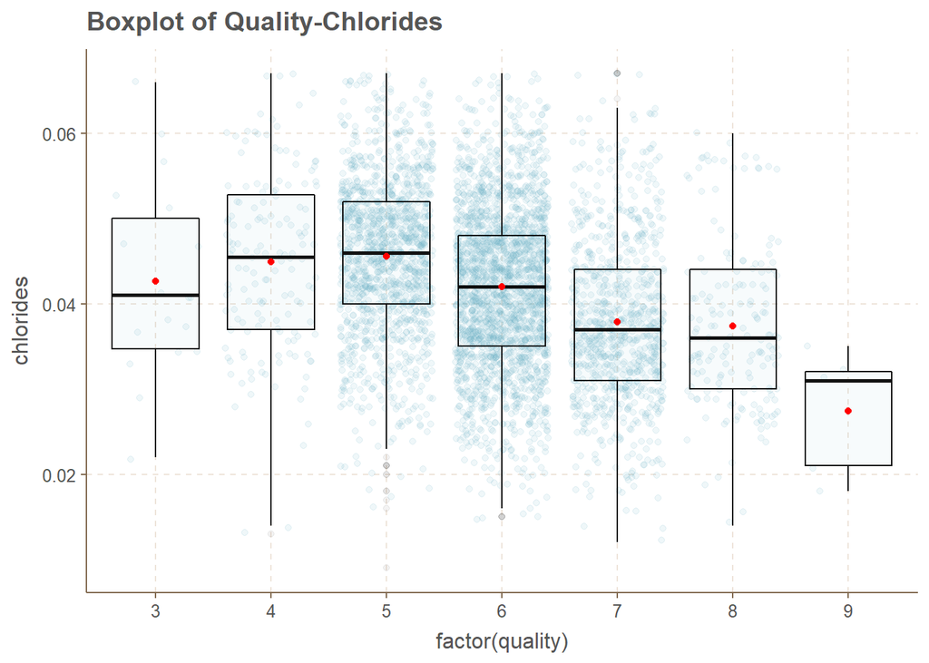

```
##
##  Pearson's product-moment correlation
##
## data:  chlorides and quality
## t = -15.024, df = 4896, p-value < 2.2e-16
## alternative hypothesis: true correlation is not equal to 0
## 95 percent confidence interval:
##  -0.2365501 -0.1830039
## sample estimates:
##        cor
## -0.2099344
```

从箱型图来看，氯化物含量与品质存在一定的负相关性，尤其是在样本比较集中的0-0.08$g/dm^3$区间内。相关性测试显示两者间有负向弱相关。

#### 密度与品质

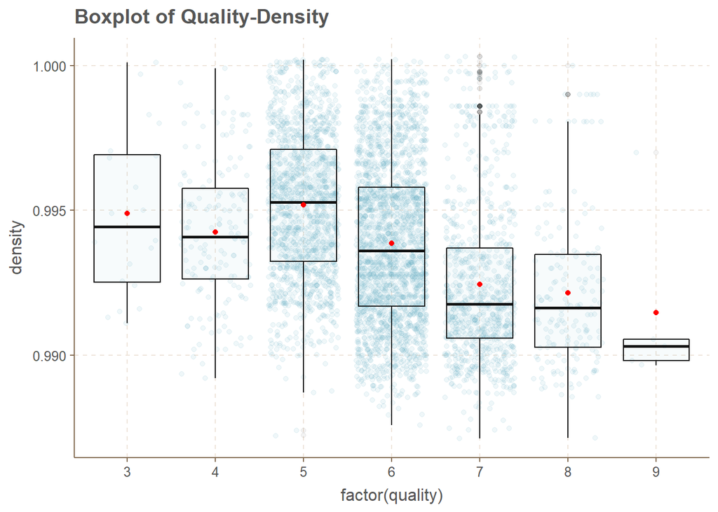

```
##
##  Pearson's product-moment correlation
##
## data:  density and quality
## t = -22.581, df = 4896, p-value < 2.2e-16
## alternative hypothesis: true correlation is not equal to 0
## 95 percent confidence interval:
##  -0.3322718 -0.2815385
## sample estimates:
##        cor
## -0.3071233
```

从箱型图来看，白葡萄酒的密度与品质存在明显的负相关性。相关性测试显示两者间有中度负相关性。

**结论:**白葡萄酒的密度与品质存在比较明显的负相关性。白葡萄酒的密度主要取决于酒精与糖分的含量。结合上方结论来看，酒精含量的提高会提高酒的风味，而残留糖分对白葡萄酒的影响不明显。因此，酒精含量越高，密度越小，酒的品质相对更好，密度与品质呈负相关关系。

#### pH与品质

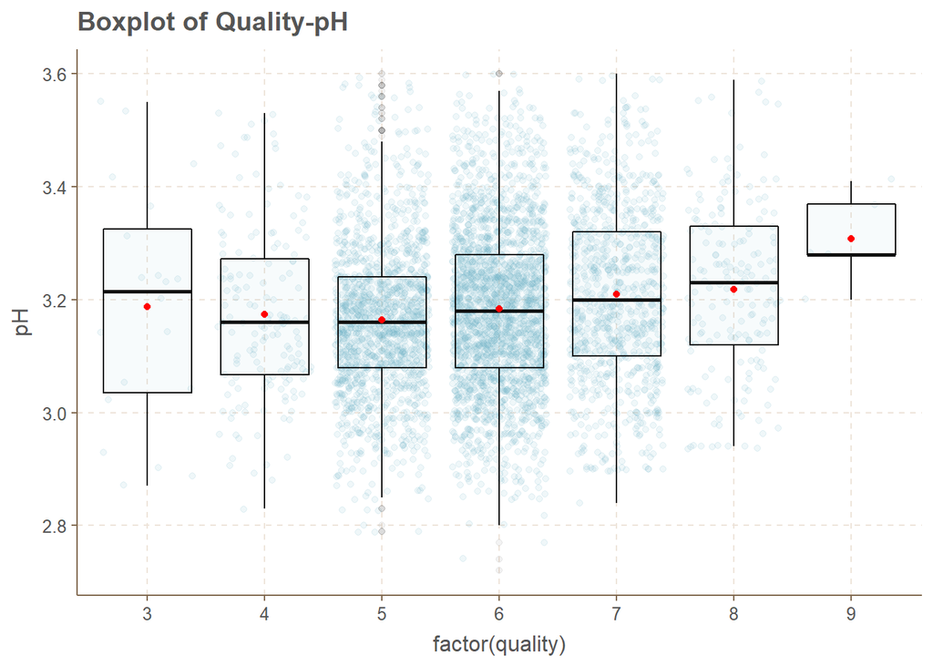

```
##
##  Pearson's product-moment correlation
##
## data:  pH and quality
## t = 6.9917, df = 4896, p-value = 3.081e-12
## alternative hypothesis: true correlation is not equal to 0
## 95 percent confidence interval:
##  0.07162022 0.12707983
## sample estimates:
##        cor
## 0.09942725
```

**结论:**从散点图和相关性测试来看，白葡萄酒的pH与品质无明显的相关关系。

**结论:**白葡萄酒的pH与品质无明显的相关关系。

## 多变量相关性分析和回归分析

根据双变量的结果，我们可以对变量进行优化，先增加柠檬酸、游离二氧化硫和总二氧化硫的适宜区间，并再一次进行相关性分析，找出与质量存在相关关系的变量。

```
##              quality              alcohol              density
##                1.000                0.436               -0.307
##           cacid_good           tsuld_good            chlorides
##                0.226                0.220               -0.210
##     volatile.acidity           fsuld_good total.sulfur.dioxide
##               -0.195                0.185               -0.175
##        fixed.acidity                   pH       residual.sugar
##               -0.114                0.099               -0.098
##            sulphates          citric.acid  free.sulfur.dioxide
##                0.054               -0.009                0.008
```

我们可以排除柠檬酸、游离二氧化硫、残留糖分、pH、硫酸盐五个与白葡萄酒品质无关的变量。并用剩下的变量进行回归分析。

```
##
## Calls:
## m1: lm(formula = quality ~ alcohol, data = wine)
## m2: lm(formula = quality ~ alcohol + density, data = wine)
## m3: lm(formula = quality ~ alcohol + density + cacid_good, data = wine)
## m4: lm(formula = quality ~ alcohol + density + cacid_good + tsuld_good,
##     data = wine)
## m5: lm(formula = quality ~ alcohol + density + cacid_good + tsuld_good +
##     chlorides, data = wine)
## m6: lm(formula = quality ~ alcohol + density + cacid_good + tsuld_good +
##     chlorides + volatile.acidity, data = wine)
## m7: lm(formula = quality ~ alcohol + density + cacid_good + tsuld_good +
##     chlorides + volatile.acidity + fsuld_good, data = wine)
## m8: lm(formula = quality ~ alcohol + density + cacid_good + tsuld_good +
##     chlorides + volatile.acidity + fsuld_good + total.sulfur.dioxide,
##     data = wine)
## m9: lm(formula = quality ~ alcohol + density + cacid_good + tsuld_good +
##     chlorides + volatile.acidity + fsuld_good + total.sulfur.dioxide +
##     fixed.acidity, data = wine)
##
## =============================================================================================================================================
##                             m1           m2           m3           m4           m5           m6           m7           m8           m9
## ---------------------------------------------------------------------------------------------------------------------------------------------
##   (Intercept)              2.582***   -22.492***   -22.030***   -30.027***   -28.872***   -39.943***   -36.899***   -28.132***   -40.242***
##                           (0.098)      (6.165)      (6.090)      (6.118)      (6.119)      (6.010)      (5.981)      (6.182)      (6.375)
##   alcohol                  0.313***     0.360***     0.339***     0.331***     0.317***     0.364***     0.356***     0.359***     0.373***
##                           (0.009)      (0.015)      (0.015)      (0.015)      (0.015)      (0.015)      (0.015)      (0.015)      (0.015)
##   density                              24.728***    24.368***    32.367***    31.440***    42.604***    39.536***    30.416***    43.141***
##                                        (6.079)      (6.005)      (6.035)      (6.033)      (5.927)      (5.899)      (6.121)      (6.340)
##   cacid_good                                         0.255***     0.254***     0.249***     0.174***     0.165***     0.168***     0.174***
##                                                     (0.023)      (0.023)      (0.023)      (0.023)      (0.023)      (0.023)      (0.022)
##   tsuld_good                                                      0.210***     0.208***     0.166***     0.119***     0.181***     0.173***
##                                                                  (0.025)      (0.025)      (0.024)      (0.025)      (0.027)      (0.027)
##   chlorides                                                                   -1.929***    -1.109*      -1.164*      -1.304*      -1.310*
##                                                                               (0.548)      (0.537)      (0.534)      (0.533)      (0.530)
##   volatile.acidity                                                                         -1.784***    -1.759***    -1.788***    -1.823***
##                                                                                            (0.113)      (0.112)      (0.112)      (0.111)
##   fsuld_good                                                                                             0.194***     0.181***     0.179***
##                                                                                                         (0.024)      (0.024)      (0.023)
##   total.sulfur.dioxide                                                                                                0.002***     0.002***
##                                                                                                                      (0.000)      (0.000)
##   fixed.acidity                                                                                                                   -0.096***
##                                                                                                                                   (0.013)
## ---------------------------------------------------------------------------------------------------------------------------------------------
##   R-squared                0.190        0.192        0.212        0.224        0.226        0.263        0.274        0.278        0.285
##   N                     4898         4898         4898         4898         4898         4898         4898         4898         4898
## =============================================================================================================================================
##   Significance: *** = p < 0.001; ** = p < 0.01; * = p < 0.05
```

#### 多变量分析

有葡萄酒爱好者认为，葡萄酒的品质在于各种风味的“平衡”。我们想要探讨酒香、酸度、甜度两两风味对葡萄酒平衡的影响。  
其中，由于柠檬酸对品讨酒品质的影响最明显，并且从资料来看，柠檬酸有明显的风味，因此我们选取柠檬酸作为酸度的代表变量。

1. 酒香与酸度

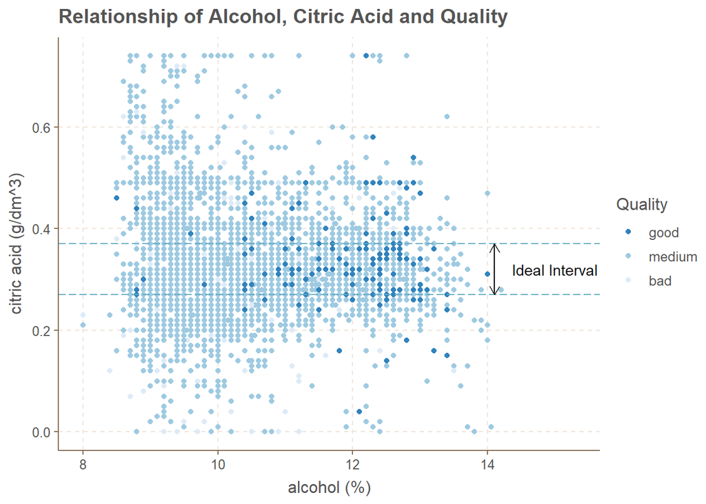

2. 酒香与甜度

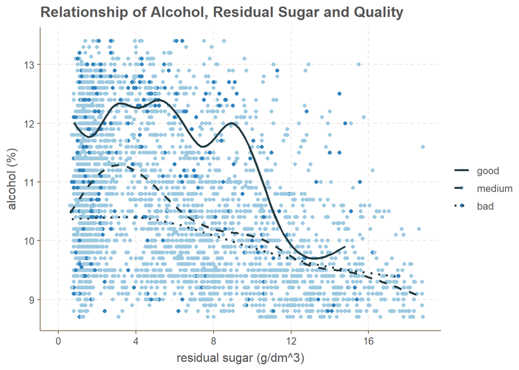

**结论:**从散点图来看，大部分高品质的酒都有高酒精度、低甜度的特点。有趣的是，对于低酒精度的优质酒中，高甜度的酒的占比会比中低品质的酒要高。高品质的低酒精度酒中，偏甜的酒会比较受欢迎。

3. 酸度与甜度

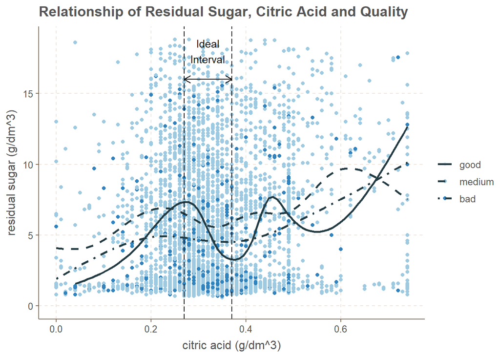

**结论:**高品质的白葡萄酒酸度集中在适宜区间，甜度大多偏低，与双变量分析结果类似。但并未发现两者之间明显的关系。

## 最终图形和摘要

在对11种化学物质对白葡萄酒品质的影响的研究中，我们发现有三个变量对白葡萄酒的影响不明显，或未发现有明显的规律性。这三个变量分别是：残留糖分(residual sugar)、pH值、硫酸盐(sulphates)。  
在对剩余其余的8个变量的研究中，我们发现三种对葡萄酒品质的影响模式：  
##### 1. 正相关/负相关  
酒精浓度(alcohol)与品质呈正相关关系。而密度(density)、氯化物(chlorides)、挥发酸(volatile acidity)和非挥发酸(fixed acidity)与品质成负相关关系。  
在这些变量当中，**酒精浓度(alcohol)**对葡萄酒品质的影响最为明显，人们更偏好于酒精浓度较高的白葡萄酒。

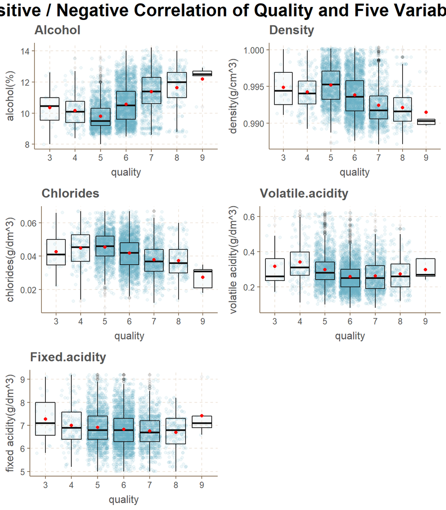

##### 2. 非线性相关-先增后减

柠檬酸(citric acid)、总二氧化硫(total sulfur dioxide)和游离二氧化硫(free sulfur dioxide)三个变量都呈现出类似的规律：随着化学物质含量的上升，白葡萄酒的品质先提高后降低。也就是说，这些化学物质的含量在一定范围内对白葡萄酒的品质最佳，过高或过低都会破坏白葡萄酒的风味。我们称这个含量区间为适宜区间。  
柠檬酸的适宜区间为0.27-0.37$g/dm^3$。 总二氧化硫的适宜区间为80-160$mg/dm^3$。 游离二氧化硫的适宜区间为22-43$mg/dm^3$。

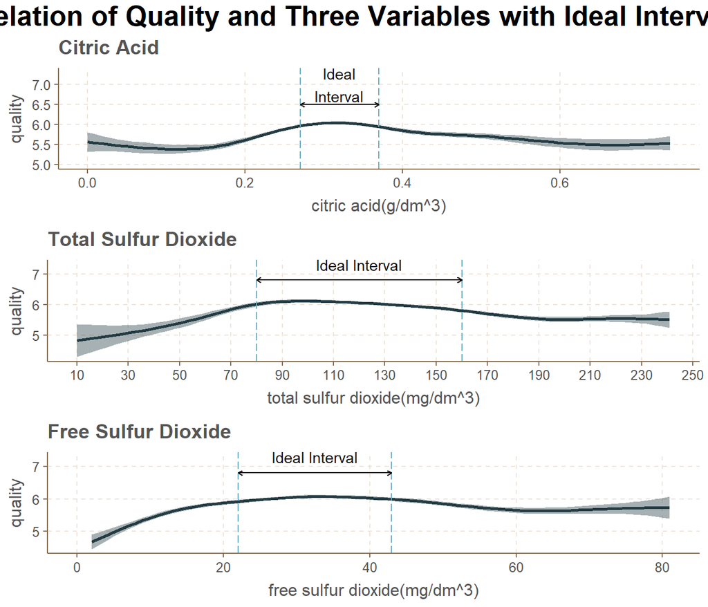

##### 3. 酒香与酸、甜的平衡

我们还发现高品质酒的酒香与酸度、甜度之间也有一定的关系。  
在前面的发现当中，我们得知酒香醇厚、酸度适中的白葡萄酒品质更高，并且一般来说甜度也不高。  
当然，不是所有高品质酒都有所有这些特征。我们将目光放在酒精浓度低的高品质酒，发现人们更偏好酸度、甜度偏高的酒。很多酒精浓度低的白葡萄酒会被用来佐餐，丰富的酸、甜风味更能够提升食物的美味。

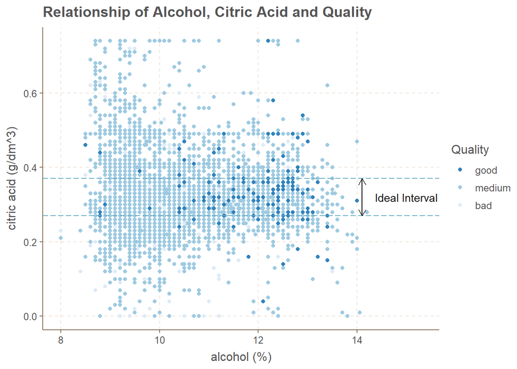

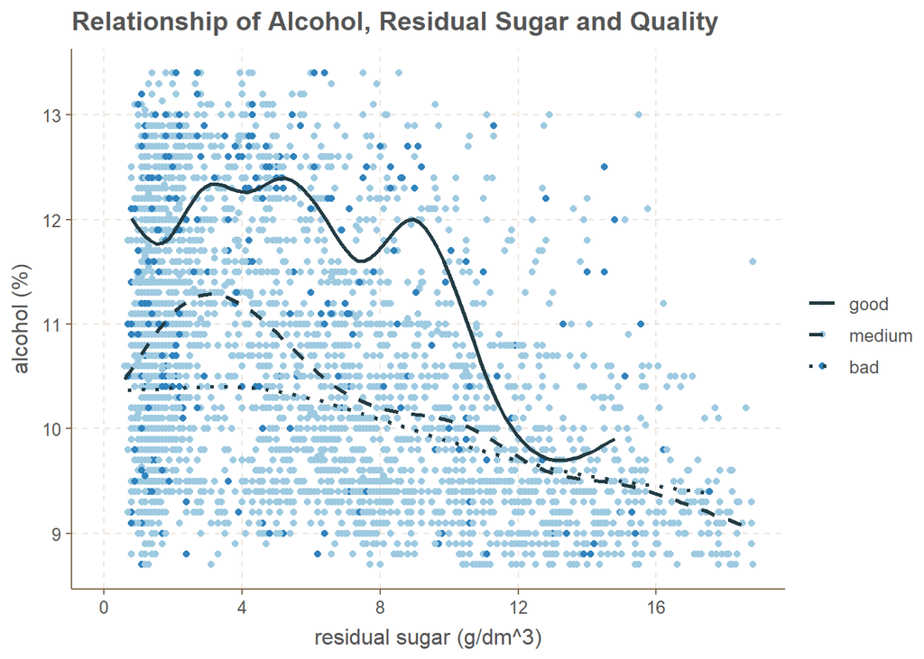

## 反思

在此次分析中，我发现这些化学物质与白葡萄酒品质没有明显的线性相关关系。通过对白葡萄酒各化学成分的进一步了解，认识其对白葡萄酒会有什么样的影响，发现白葡萄酒中的部分化学物质含量需要“适量”，过高或过低都可能破坏葡萄酒的风味。因此，在对柠檬酸、总二氧化硫和游离二氧化硫的时候，我试图找到它们的适宜区间，并生成一个dummy变量——含量是否在适宜区间内。利用生成的三个dummy变量，发现在做回归分析的时候效果会更佳。  
遇到的另一个问题是，高分样本少，92.6% 的样本都是5-7分。又由于白葡萄酒的影响变量太多，好的葡萄酒需要各种化学物质都在合适的范围，而随便一种化学物质过高或过低，就会破坏整瓶葡萄酒的风味，所以可能其他所有变量符合高品质酒的标准，但他的分数还是低。这样，我们很难辨别低分样本是由什么变量造成的。对于此问题，我将我们探索的问题转化为“高品质的酒会有什么样的特征”，更多地分析高分样本，从而得出结论。 此次分析还是有未尽之处： 1. 建立的多变量线性回归模型拟合效果不佳，$R^2$最高只有0.285。可以尝试通过非线性模型或其他更合适的模型进行拟合。 2. 还可以结合红葡萄酒的样本，分析白葡萄酒、红葡萄酒的异同。